# Tugas Praktikum Kelompok 7

Praktikum 4 — Visualisasi Data

Author

Emanuel Marthen Embuai (M0501261019)  
Raihanindita Jasmine (M0501261033)  
Yuvani Oksarianti (M0501261008)

Published

September 13, 2026

## 1. Pembersihan Data Mahasiswa

**1.1 Buat data frame bernama nilai_raw secara manual di R berdasarkan Tabel 1.**

```r
nilai_raw <- data.frame(
  Nama = c("Andi", "Budi", "Citra", "Dewi", "Andi"),
  Matematika = c(80,90, NA, 75, 80),
  Statistika = c(85, 88, 78, "-", 85),
  Umur = c(21, 20, 22, 21, 21),
  stringsAsFactors = FALSE
)
nilai_raw
```

| Nama | Matematika | Statistika | Umur |
| --- | --- | --- | --- |
| Andi | 80 | 85 | 21 |
| Budi | 90 | 88 | 20 |
| Citra | NA | 78 | 22 |
| Dewi | 75 | - | 21 |
| Andi | 80 | 85 | 21 |

**1.2 Identifikasi nilai yang hilang pada dataset secara sistematis. Ubah tanda hubung (“-”) pada nilai Statistika milik Dewi menjadi nilai hilang standar R, yaitu NA.**

```r
sum(is.na(nilai_raw))
```

```
[1] 1
```

```r
nilai_raw$Statistika[nilai_raw$Nama == "Dewi" & nilai_raw$Statistika == "-"] <- NA

nilai_raw$Statistika <-as.numeric(nilai_raw$Statistika)

nilai_raw
```

| Nama | Matematika | Statistika | Umur |
| --- | --- | --- | --- |
| Andi | 80 | 85 | 21 |
| Budi | 90 | 88 | 20 |
| Citra | NA | 78 | 22 |
| Dewi | 75 | NA | 21 |
| Andi | 80 | 85 | 21 |

```r
sum(is.na(nilai_raw))
```

```
[1] 2
```

**1.3 Lakukan imputasi terhadap nilai Statistika yang kosong menggunakan rata-rata nilai Statistika mahasiswa lainnya yang tersedia.**

```r
nilai_raw$Statistika[is.na(nilai_raw$Statistika)] <- round(mean(nilai_raw$Statistika, na.rm = TRUE), 2)

nilai_raw
```

| Nama | Matematika | Statistika | Umur |
| --- | --- | --- | --- |
| Andi | 80 | 85 | 21 |
| Budi | 90 | 88 | 20 |
| Citra | NA | 78 | 22 |
| Dewi | 75 | 84 | 21 |
| Andi | 80 | 85 | 21 |

**1.4 Buat kolom baru bernama Status_Umur menggunakan fungsi ifelse() dengan ketentuan: Dewasa jika umur ≥ 21 tahun; Muda jika umur < 21 tahun.**

```r
nilai_raw$Status_Umur <- ifelse (nilai_raw$Umur >= 21, "Dewasa", "Muda")
nilai_raw
```

| Nama | Matematika | Statistika | Umur | Status_Umur |
| --- | --- | --- | --- | --- |
| Andi | 80 | 85 | 21 | Dewasa |
| Budi | 90 | 88 | 20 | Muda |
| Citra | NA | 78 | 22 | Dewasa |
| Dewi | 75 | 84 | 21 | Dewasa |
| Andi | 80 | 85 | 21 | Dewasa |

**1.5 Identifikasi dan hapus baris pengamatan yang duplikat.**

```r
#cek baris duplikat
nilai_raw[duplicated(nilai_raw),]
```

|  | Nama | Matematika | Statistika | Umur | Status_Umur |
| --- | --- | --- | --- | --- | --- |
| 5 | Andi | 80 | 85 | 21 | Dewasa |

```r
#hapus baris duplikat
nilai_bersih <- unique(nilai_raw)
nilai_bersih
```

|  | Nama | Matematika | Statistika | Umur | Status_Umur |
| --- | --- | --- | --- | --- | --- |
| 1 | Andi | 80 | 85 | 21 | Dewasa |
| 2 | Budi | 90 | 88 | 20 | Muda |
| 3 | Citra | NA | 78 | 22 | Dewasa |
| 4 | Dewi | 75 | 84 | 21 | Dewasa |

**1.6 Simpan dataset yang telah dibersihkan ke dalam file bernama nilai_bersih.csv.**

```r
write.csv(nilai_bersih, file = "nilai_bersih.csv", row.names = FALSE)
```

## 2. Subsetting dan Pengurutan Multikriteria

**2.1 Buat data frame bernama profil secara manual di R berdasarkan Tabel.**

```r
profil <- data.frame(
  No = 1:10,
  gender = c("f","f","f","m","m","f","m","m","f","m"),
  v1 = c(8,15,8,14,8,10,9,9,10,12),
  v2 = c(9, 8, 13, 9, 2, 6, 9, 10, 13, 10),
  v3 = c(5, 9, 12, 8, 9, 10, 7, 8, 6, 9),
  v4 = c(9, 5, 6, NA, 16, 9, 13, 10, 7, 8),
  v5 = c(9, 10, 7, 11, 8, 10, 9, 5, 10, 17),
  v6 = c(9, 8, 9, 10, 10, 10, 12, 10, 12, 7),
  v7 = c(5, 10, 14, 6, 8, 9, 10, 6, 13, 9),
  v8 = c(9, 12, 12, 11, 9, 7, 9, 12, 9, 10),
  v9 = c(11, 9, 12, 11, 8, 7, 11, 6, 6, 7),
  v10 = c(8, 15, 9, 8, 9, 11, 7, 8, 9, 7)
)

profil
```

| No | gender | v1 | v2 | v3 | v4 | v5 | v6 | v7 | v8 | v9 | v10 |
| --- | --- | --- | --- | --- | --- | --- | --- | --- | --- | --- | --- |
| 1 | f | 8 | 9 | 5 | 9 | 9 | 9 | 5 | 9 | 11 | 8 |
| 2 | f | 15 | 8 | 9 | 5 | 10 | 8 | 10 | 12 | 9 | 15 |
| 3 | f | 8 | 13 | 12 | 6 | 7 | 9 | 14 | 12 | 12 | 9 |
| 4 | m | 14 | 9 | 8 | NA | 11 | 10 | 6 | 11 | 11 | 8 |
| 5 | m | 8 | 2 | 9 | 16 | 8 | 10 | 8 | 9 | 8 | 9 |
| 6 | f | 10 | 6 | 10 | 9 | 10 | 10 | 9 | 7 | 7 | 11 |
| 7 | m | 9 | 9 | 7 | 13 | 9 | 12 | 10 | 9 | 11 | 7 |
| 8 | m | 9 | 10 | 8 | 10 | 5 | 10 | 6 | 12 | 6 | 8 |
| 9 | f | 10 | 13 | 6 | 7 | 10 | 12 | 13 | 9 | 6 | 9 |
| 10 | m | 12 | 10 | 9 | 8 | 17 | 7 | 9 | 10 | 7 | 7 |

**2.2 Lakukan penyaringan (subsetting) sehingga hanya menyisakan pengamatan yang memenuhi salah satu kondisi berikut: gender laki-laki (m) dan v1 > 9 ; atau gender perempuan (f) dan v3 <= 10.**

```r
profil_subset <- profil[(profil$gender == "m" & profil$v1 > 9) | (profil$gender == "f" & profil$v3 <= 10), ]
profil_subset
```

|  | No | gender | v1 | v2 | v3 | v4 | v5 | v6 | v7 | v8 | v9 | v10 |
| --- | --- | --- | --- | --- | --- | --- | --- | --- | --- | --- | --- | --- |
| 1 | 1 | f | 8 | 9 | 5 | 9 | 9 | 9 | 5 | 9 | 11 | 8 |
| 2 | 2 | f | 15 | 8 | 9 | 5 | 10 | 8 | 10 | 12 | 9 | 15 |
| 4 | 4 | m | 14 | 9 | 8 | NA | 11 | 10 | 6 | 11 | 11 | 8 |
| 6 | 6 | f | 10 | 6 | 10 | 9 | 10 | 10 | 9 | 7 | 7 | 11 |
| 9 | 9 | f | 10 | 13 | 6 | 7 | 10 | 12 | 13 | 9 | 6 | 9 |
| 10 | 10 | m | 12 | 10 | 9 | 8 | 17 | 7 | 9 | 10 | 7 | 7 |

**2.3 Urutkan data hasil penyaringan secara multikriteria, dengan ketentuan: gender diurutkan secara descending; untuk pengamatan dengan gender yang sama, v5 diurutkan secara ascending.**

```r
profil_filter<- profil_subset[order(-as.integer(factor(profil_subset$gender)), profil_subset$v5),]

profil_filter
```

|  | No | gender | v1 | v2 | v3 | v4 | v5 | v6 | v7 | v8 | v9 | v10 |
| --- | --- | --- | --- | --- | --- | --- | --- | --- | --- | --- | --- | --- |
| 4 | 4 | m | 14 | 9 | 8 | NA | 11 | 10 | 6 | 11 | 11 | 8 |
| 10 | 10 | m | 12 | 10 | 9 | 8 | 17 | 7 | 9 | 10 | 7 | 7 |
| 1 | 1 | f | 8 | 9 | 5 | 9 | 9 | 9 | 5 | 9 | 11 | 8 |
| 2 | 2 | f | 15 | 8 | 9 | 5 | 10 | 8 | 10 | 12 | 9 | 15 |
| 6 | 6 | f | 10 | 6 | 10 | 9 | 10 | 10 | 9 | 7 | 7 | 11 |
| 9 | 9 | f | 10 | 13 | 6 | 7 | 10 | 12 | 13 | 9 | 6 | 9 |

**2.4 Simpan hasil akhir ke dalam file bernama profil_filter.csv.**

```r
write.csv(profil_filter, file = "profil_filter.csv", row.names = FALSE)
```

## 3. Penggabungan dan Reshaping Data

Diberikan dua data frame mengenai skor penjualan mingguan beberapa toko berikut.

```r
df_sales <- data.frame(
  id_toko = c("T1", "T2", "T3"),
  Minggu1 = c(120, 150, 95),
  Minggu2 = c(135, 140, 110)
)

df_info <- data.frame(
  id = c("T1", "T2", "T4"),
  Kota = c("Jakarta", "Bandung", "Surabaya")
)
```

```r
df_info
```

| id | Kota |
| --- | --- |
| T1 | Jakarta |
| T2 | Bandung |
| T4 | Surabaya |

```r
df_sales
```

| id_toko | Minggu1 | Minggu2 |
| --- | --- | --- |
| T1 | 120 | 135 |
| T2 | 150 | 140 |
| T3 | 95 | 110 |

**3.1 Gabungkan df_sales dan df_info menggunakan fungsi merge() dengan metode Full Outer Join, sehingga seluruh toko dari kedua data frame tetap disertakan. Perhatikan bahwa nama variabel kunci pada kedua data frame berbeda, yaitu id_toko pada df_sales dan id pada df_info. Gunakan argumen penggabungan yang sesuai.**

```r
#merge dua data frame

df_merge<-merge(df_sales,df_info,by.x="id_toko",by.y="id", all = TRUE)
df_merge
```

| id_toko | Minggu1 | Minggu2 | Kota |
| --- | --- | --- | --- |
| T1 | 120 | 135 | Jakarta |
| T2 | 150 | 140 | Bandung |
| T3 | 95 | 110 | NA |
| T4 | NA | NA | Surabaya |

**3.2 Ubah struktur data hasil penggabungan dari format Wide menjadi Long, sehingga: Minggu1 dan Minggu2 digabung menjadi satu kolom bernama Waktu; nilai penjualan disimpan dalam satu kolom bernama Penjualan.**

```r
#mengubah ke data long

df_wide <- df_merge

data_long <- pivot_longer(
  df_wide,
  cols = c(Minggu1, Minggu2),
  names_to = "Waktu",
  values_to = "Penjualan"
)

data_long
```

| id_toko | Kota | Waktu | Penjualan |
| --- | --- | --- | --- |
| T1 | Jakarta | Minggu1 | 120 |
| T1 | Jakarta | Minggu2 | 135 |
| T2 | Bandung | Minggu1 | 150 |
| T2 | Bandung | Minggu2 | 140 |
| T3 | NA | Minggu1 | 95 |
| T3 | NA | Minggu2 | 110 |
| T4 | Surabaya | Minggu1 | NA |
| T4 | Surabaya | Minggu2 | NA |

**3.3 Simpan dataset dalam format Long tersebut ke dalam file bernama penjualan_long.csv.**

```r
write.csv(data_long, file = "penjualan_long.csv", row.names = FALSE)
```

## 4. Eksplorasi Visual

Gunakan dataset bawaan R CO2 untuk mengeksplorasi hubungan antara konsentrasi karbon dioksida (conc) dan tingkat penyerapan karbon dioksida (uptake) pada tanaman.

**4.1 Kenali struktur dataset CO2 dan identifikasi peran peubah Plant, Type, Treatment, conc, dan uptake, kemudian buat grafik menggunakan base R untuk menunjukkan hubungan conc dan uptake dengan mengatur bentuk dan ukuran titik, warna, judul, label sumbu, serta rentang sumbu, lalu tambahkan minimal dua elemen grafik menggunakan points(), lines(), abline(), atau text().**

```r
# Cek data dan bentuk data.

CO2
```

|  | Plant | Type | Treatment | conc | uptake |
| --- | --- | --- | --- | --- | --- |
| 1 | Qn1 | Quebec | nonchilled | 95 | 16.0 |
| 2 | Qn1 | Quebec | nonchilled | 175 | 30.4 |
| 3 | Qn1 | Quebec | nonchilled | 250 | 34.8 |
| 4 | Qn1 | Quebec | nonchilled | 350 | 37.2 |
| 5 | Qn1 | Quebec | nonchilled | 500 | 35.3 |
| 6 | Qn1 | Quebec | nonchilled | 675 | 39.2 |
| 7 | Qn1 | Quebec | nonchilled | 1000 | 39.7 |
| 8 | Qn2 | Quebec | nonchilled | 95 | 13.6 |
| 9 | Qn2 | Quebec | nonchilled | 175 | 27.3 |
| 10 | Qn2 | Quebec | nonchilled | 250 | 37.1 |

[output cut: 74 more lines]

```r
glimpse(CO2)
```

```
Rows: 84
Columns: 5
$ Plant     <ord> Qn1, Qn1, Qn1, Qn1, Qn1, Qn1, Qn1, Qn2, Qn2, Qn2, Qn2, Qn2, …
$ Type      <fct> Quebec, Quebec, Quebec, Quebec, Quebec, Quebec, Quebec, Queb…
$ Treatment <fct> nonchilled, nonchilled, nonchilled, nonchilled, nonchilled, …
$ conc      <dbl> 95, 175, 250, 350, 500, 675, 1000, 95, 175, 250, 350, 500, 6…
$ uptake    <dbl> 16.0, 30.4, 34.8, 37.2, 35.3, 39.2, 39.7, 13.6, 27.3, 37.1, …
```

```r
names(CO2)
```

```
[1] "Plant"     "Type"      "Treatment" "conc"      "uptake"
```

```r
# Menyesuaikan tipe data setiap peubah sebelum digunakan untuk visualisasi.

# Mengubah Plant menjadi ordered factor agar identitas tanaman tersimpan sebagai kategori berurutan.
Plant <- factor(CO2$Plant, ordered = TRUE)

# Mengubah Type menjadi factor karena merupakan variabel kategorik (Quebec/Mississippi).
Type <- as.factor(CO2$Type)

# Mengubah Treatment menjadi factor karena merupakan variabel kategorik (chilled/nonchilled).
Treatment <- as.factor(CO2$Treatment)

# Menyimpan peubah konsentrasi CO2 (variabel numerik untuk sumbu X).
Conc <- CO2$conc

# Menyimpan peubah laju penyerapan CO2 (variabel numerik untuk sumbu Y).
Uptake <- CO2$uptake
```

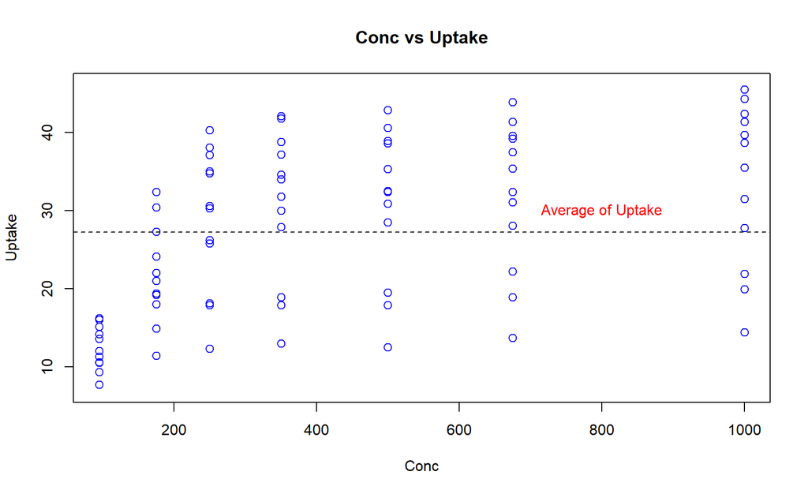

```r
#Melakukan Plotting dari Conc vs Uptake

plot(
  x = Conc,
  y = Uptake,
  pch = 1,
  cex = 1.2,
  col = "blue",
  main = "Conc vs Uptake",
  xlab = "Conc",
  ylab = "Uptake",
  xlim = c(95, 1000),
  ylim = c(7, 46)
)
abline(h = mean(CO2$uptake), lty = 2)
text(x = 800, y = 30, "Average of Uptake", col = "red")
```

**4.2 Buat satu tampilan grafik berukuran 2 × 2 yang terdiri atas empat jenis visualisasi berbeda untuk mengeksplorasi conc, uptake, Type, dan Treatment; tentukan sendiri jenis grafik yang paling sesuai dan berikan judul yang jelas pada setiap grafik.**

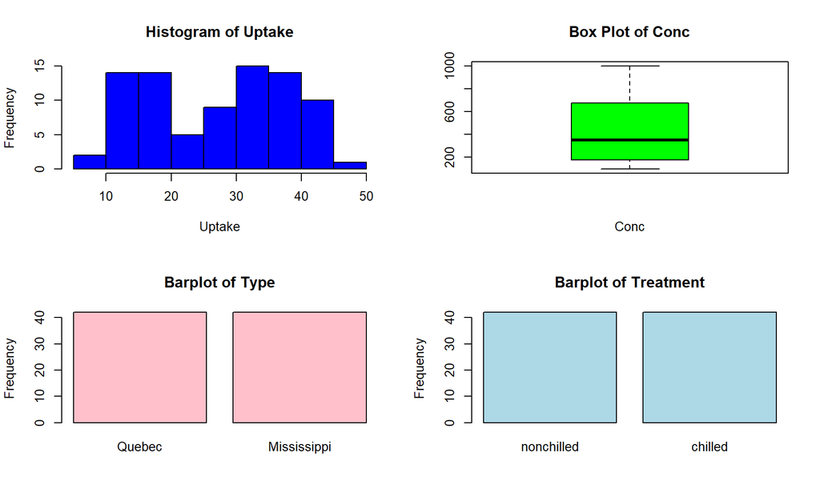

```r
# Inisialisasi tempat dari ke 4 grafik atau par.

par(mfrow = c(2,2))

hist(Uptake, main = "Histogram of Uptake", xlab = "Uptake", col = "Blue")

boxplot(Conc, main = "Box Plot of Conc", xlab = "Conc", col = "Green")

barplot(table(CO2$Type),
        main = "Barplot of Type",
        ylab = "Frequency",
        col="pink")

barplot(table(CO2$Treatment),
        main = "Barplot of Treatment",
        ylab = "Frequency",
        col="lightblue")
```

**4.3 Gunakan qplot() untuk membuat visualisasi cepat hubungan conc dan uptake berdasarkan Treatment, kemudian buat kembali visualisasi tersebut menggunakan ggplot2 dengan memetakan Treatment dan Type ke atribut visual yang berbeda di dalam aes() serta menggunakan geom_* yang sesuai.**

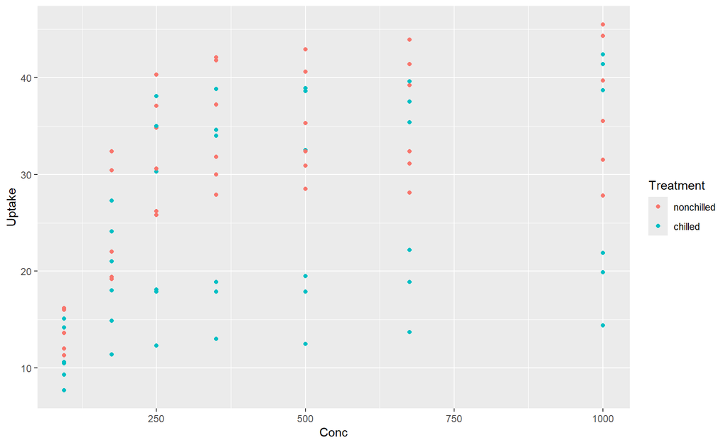

```r
qplot(
  x = Conc,
  y = Uptake,
  colour = Treatment,
  data = CO2
)
```

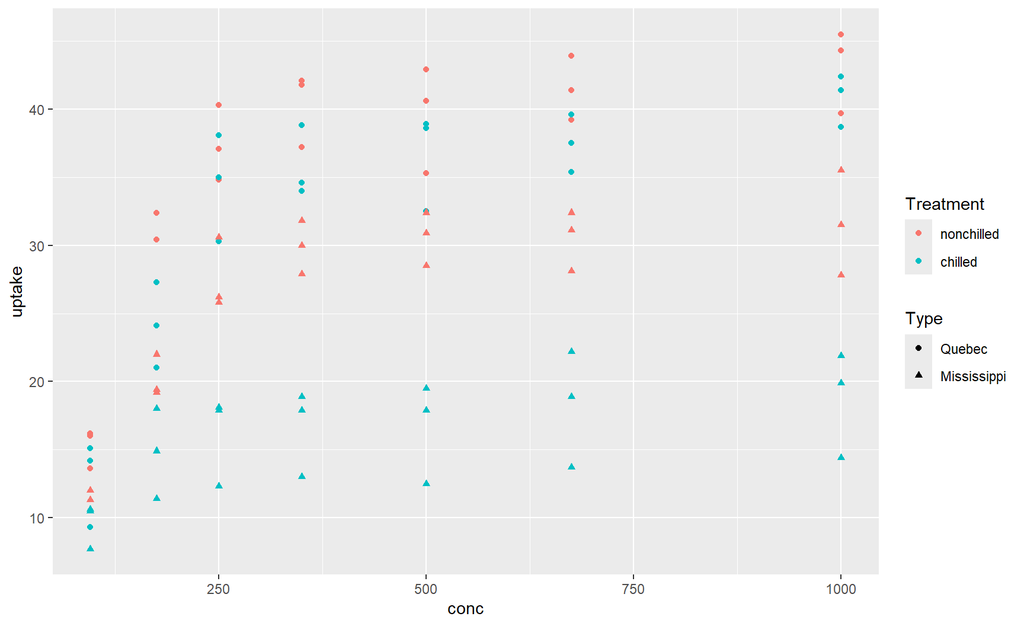

```r
ggplot(
  data = CO2,
  aes(
    x = conc,
    y = uptake,
    color = Treatment,
    shape = Type
  )
) +
  geom_point()
```

**4.4 Kembangkan grafik ggplot2 tersebut dengan menambahkan minimal satu stat_*, satu scale_*, serta salah satu coord_*, kemudian lengkapi grafik menggunakan labs() dan theme() atau salah satu tema siap pakai agar grafik lebih informatif dan mudah dibaca.**

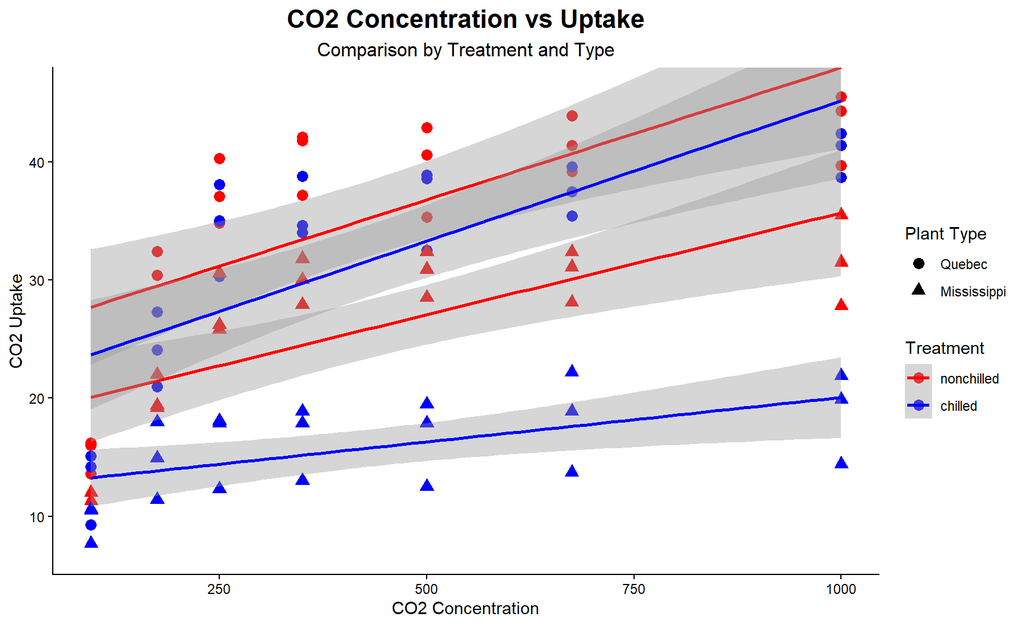

```r
grafik_final <- ggplot(
  data = CO2,
  aes(
    x = conc,
    y = uptake,
    color = Treatment,
    shape = Type
  )
) +
  geom_point(size=3) +
  stat_smooth(
    method = "lm"
  ) +
  scale_color_manual(
    values = c("red","blue")
  ) + coord_cartesian(
    xlim = c(94, 1000),
    ylim = c(7, 46)
  ) + labs(
    title = "CO2 Concentration vs Uptake",
    subtitle = "Comparison by Treatment and Type",
    x = "CO2 Concentration",
    y = "CO2 Uptake",
    color = "Treatment",
    shape = "Plant Type"
  ) +
  theme_classic() +
  theme(
    plot.title = element_text(hjust = 0.5, face = "bold", size = 16),
    plot.subtitle = element_text(hjust = 0.5, size = 12)
  )

grafik_final
```

**4.5 Simpan grafik akhir menggunakan ggsave() dalam format PNG dengan nama co2_uptake_visualisasi.png, kemudian tuliskan interpretasi mengenai hubungan antara konsentrasi CO₂ dan uptake serta perbedaan pola yang terlihat berdasarkan Type dan Treatment.**

```r
ggsave(
  filename ="co2_uptake_visualisasi.png",
  plot = grafik_final)
```

Interpretasi:

Grafik menunjukkan hubungan antara konsentrasi CO₂ (conc) dengan laju penyerapan CO₂ (uptake) pada tanaman berdasarkan tipe tanaman (Type) dan perlakuan (Treatment).

1. Hubungan antara konsentrasi CO₂ dan uptake

Terdapat hubungan positif antara konsentrasi CO₂ dan nilai uptake. Semakin tinggi konsentrasi CO₂, semakin tinggi pula kemampuan tanaman menyerap CO₂. Hal ini terlihat dari seluruh garis regresi yang memiliki kemiringan positif. Peningkatan ini menunjukkan bahwa kenaikan konsentrasi CO₂ cenderung meningkatkan laju fotosintesis tanaman, meskipun besar peningkatannya berbeda pada setiap kelompok.

2. Perbedaan berdasarkan Type

Tanaman Quebec (simbol lingkaran) secara umum memiliki nilai uptake yang lebih tinggi dibandingkan tanaman Mississippi (simbol segitiga) pada konsentrasi CO₂ yang sama. Pada konsentrasi CO₂ yang tinggi (sekitar 675–1000 ppm), perbedaan tersebut semakin terlihat karena nilai uptake Quebec meningkat lebih besar dibandingkan Mississippi.

3. Perbedaan berdasarkan Treatment

Tanaman dengan perlakuan nonchilled (garis merah) memiliki nilai uptake yang lebih tinggi dibandingkan tanaman chilled (garis biru) pada hampir seluruh tingkat konsentrasi CO₂. Hal ini mengindikasikan bahwa perlakuan pendinginan (chilled) menurunkan kemampuan tanaman dalam menyerap CO₂.

5. Interval kepercayaan

Area abu-abu di sekitar garis regresi merupakan interval kepercayaan (confidence interval). Interval ini menunjukkan adanya variasi pada data, namun secara keseluruhan tren peningkatan uptake terhadap kenaikan konsentrasi CO₂ tetap konsisten pada semua kelompok.

**Kesimpulan:** Secara keseluruhan, grafik menunjukkan bahwa peningkatan konsentrasi CO₂ berpengaruh positif terhadap uptake tanaman. Selain itu, tipe tanaman Quebec cenderung memiliki kemampuan penyerapan CO₂ yang lebih tinggi dibandingkan Mississippi, sedangkan perlakuan nonchilled menghasilkan uptake yang lebih baik dibandingkan chilled. Kombinasi Quebec–nonchilled merupakan kelompok dengan performa penyerapan CO₂ terbaik, sedangkan Mississippi–chilled menunjukkan performa terendah.